# hw5

## Hints:

1. The US nuclear reactor table doesn’t behave nicely—why? Read through the assumptions of `html_table`.
2. As you try to clean the French nuclear reactor data, one of the dates will not parse—why? You can ignore this particular row.
3. You’ll need to fix the column names! No `dplyr` function will handle this correctly since the columns are not unique. You’ll have to rely on the class `names()` function.
4. The size of the points in the France-Japan scatterplot is 2.
5. The geometries in the Japan Construction graph are segments.
6. You’ll have to play with the `breaks` and `labels` of both axes.
7. If you use `date_format`, you’ll need to load the `ggplot2` library extension `scales`.
8. By default, strings are alphabetized for graphing. If you turn the data into an ordered factor however…
9. All the reactors are present, but only one instance of the reactor name shows up for each reactor site. For example `Tsuruga 1` and `Tsuruga 2` both show up under `Tsuruga` with the second one being represented by a tick with no label.
10. Empty strings don’t show up…

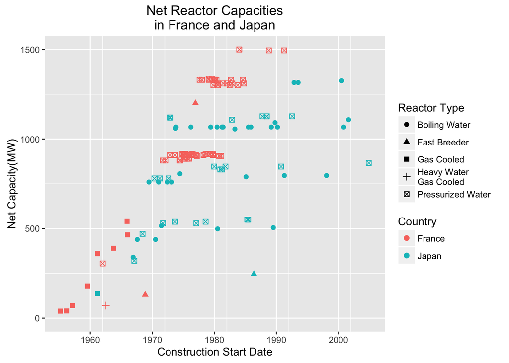

```r
# link the xpath of the data table from wikipedia onto R
new_names <- c("name", "reactor", "type", "model", "status",
               "net", "gross", "const_start", "op_start", "closure", "Country")

page = "http://en.wikipedia.org/wiki/List_of_nuclear_reactors"
xpath = '//*[@id="mw-content-text"]/table'
table_list = page %>%
  # Make the table readable in r format
  read_html() %>%
  html_nodes(xpath = xpath) %>%
  # Extract both Japan and France tables and create an html table
  .[c(16,23)] %>%
  html_table(fill = TRUE)

# Turn both tables into seperate data frames, then bind
# the dataframes together to create one data set

japan = data.frame(table_list[2]) %>%
  mutate(Country = "Japan")
df = data.frame(table_list[1]) %>%
  mutate(Country = "France") %>%
  rbind(japan) %>%
  ## Remove unneccesary rows
  .[-c(1,75),]

names(df) = c(new_names)
# Rename the columns

# Convert data into integer and date for the graph's variables
df = mutate(df, net = as.integer(net)) %>%
  mutate(const_start = as.Date(const_start, "%d %B %Y")) %>%

  # Relabel the levels of the Reactor Types
  mutate(type = factor(type,
                levels = c("BWR", "FBR", "GCR", "HWGCR", "PWR"),
                labels = c("Boiling Water", "Fast Breeder", "Gas Cooled",
                           "Heavy Water\nGas Cooled", "Pressurized Water")))

#Plotting the information
ggplot(df[which(df$type!= ""), ]) +
  geom_point(aes(x = const_start,
                 y = net, shape = type, color = Country), size = 2) +
  labs(title = "Net Reactor Capacities\nin France and Japan",
       x = "Construction Start Date",
       y = "Net Capacity(MW)", shape = "Reactor Type") +
  scale_y_continuous(breaks = seq(0, 1500, by = 500),
                     limits = c(0, 1500)) +

  # Scaling by the years
  scale_x_date(name = "Construction Start Date", date_labels = "%Y",
               limits = c(min(df$const_start), ymd(20050101)),
               date_minor_breaks = "10 years") +
  guides(colour = guide_legend(order = 2),
         shape = guide_legend(order = 1))
```

[figure not shown]

```r
japan = df[which(df$Country=="Japan"),] %>%
  .[-1,]

names(japan) = c(new_names)

switch = function(x){

  ifelse(str_detect(x, ".*1$"), str_replace(x, "1", ""), FALSE)
}

japan <- japan %>%
  mutate(const_start = as.Date(const_start, "%d %B %Y")) %>%
  mutate(op_start = as.Date(op_start, "%d %B %Y")) %>%
  mutate(type = factor(type,
                levels = c("BWR", "FBR", "GCR", "PWR"),
                labels = c("Boiling Water", "Fast Breeder", "Gas Cooled",
                           "Pressurized Water"))) %>%

  mutate(newname = str_c(name,reactor,sep="")) %>%
  mutate(newname = factor(newname)) %>%
  mutate(newname = factor(newname, levels = rev(levels(newname))))


japan$new=unlist(lapply(japan$newname, switch))

##Plot the data

ggplot(japan[which(japan$type!= ""),]) +
  geom_segment(aes(x = const_start,
                   y = newname,
                   xend = op_start,
                   yend = newname,
                   color = type)) +
  labs(title = "Contruction Times for \n Japanese Nuclear Reactors",
       x = "Date", y = "Reactor Site", color = "Reactor Type") +
 scale_x_date(name = "Date", date_labels = "%Y",
              breaks = seq(ymd(19600101), ymd(20100101), by="5 years"))
```